[figure not shown]

# **Project 1 - DualLens Analytics**

**Student Information**

**Name:** Luis Angel Cabanillas Leyva

**Cohort:** March 2026 - Saturdays

[figure not shown]

### **Background Story**

In the rapidly evolving world of finance and technology, investors are constantly seeking ways to make smarter decisions by combining traditional financial analysis with emerging technological insights. While stock market trends provide a numerical perspective on growth, an organization’s initiatives in cutting-edge fields like Artificial Intelligence (AI) reveal its future readiness and innovation potential. However, analyzing both dimensions - quantitative financial performance and qualitative AI initiatives - requires sifting through multiple, diverse data sources: stock data from platforms like Yahoo Finance, reports in PDFs, and contextual reasoning using Large Language Models (LLMs).

This is where **DualLens Analytics** comes in. By applying a dual-lens approach, the project leverages **Retrieval-Augmented Generation (RAG)** to merge **financial growth data** with **strategic insights from organizational reports**. Stock data provides evidence of stability and momentum, while AI initiative documents reveal forward-looking innovation. Together, they form a richer, more holistic picture of organizational potential.

With DualLens Analytics, investors no longer need to choose between numbers and narratives—they gain a unified, AI-driven perspective that ranks organizations by both financial strength and innovation readiness, enabling smarter, future-focused investment strategies.

### **Problem Statement**

Traditional investment analysis often focuses on financial metrics alone (e.g., stock growth, revenue, market cap), missing the qualitative dimension of how prepared a company is for the future. On the other hand, qualitative documents like strategy PDFs contain valuable insights about innovation and AI initiatives, but they are difficult to structure, query, and integrate with numeric financial data.

This leads to three core challenges:

1. **Fragmented Data Sources:** Financial data (stock prices) and strategic insights (PDFs) exist in silos.
2. **Limited Analytical Scope:** Manual analysis of growth trends and PDF reports is time-consuming and error-prone.
3. **Decisional Blind Spots:** Without integrating both quantitative (growth trends) and qualitative (AI initiatives) signals, investors may miss out on high-potential organizations.

### **Solution Approach**

To address this challenge, we set out to build a **Retrieval-Augmented Generation (RAG)** powered system that blends financial trends with AI-related strategic insights, helping investors rank organizations based on growth trajectory and innovation capacity.

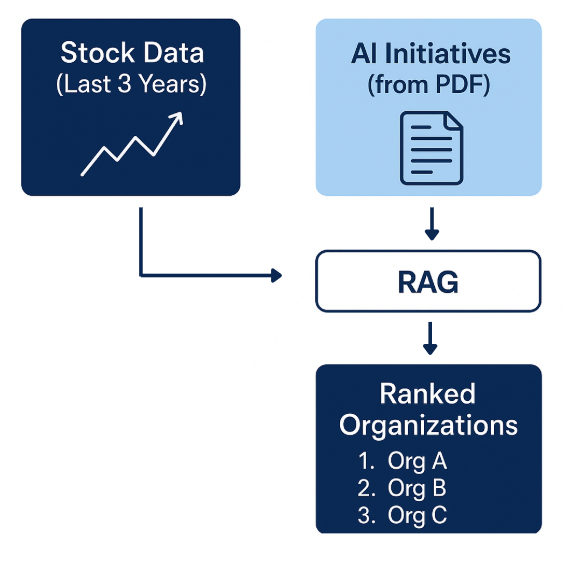

### **# Important Points To Note**

1. For LLM please use **`"gpt-4o-mini"`** model.
2. You need to look for **`"--- --- ---"`** and add your code over there, this is a placeholder.
3. For project submission, please provide the project in **HTML format.** Refer to the **"Guidelines: Converting IPYNB to HTML Files.pdf"** for instructions.
4. Ensure all **outputs are clearly visible,** and enclose prompts in triple quotes **`"""`** so they remain fully visible when the notebook is converted from IPYNB to HTML.

# **Setting up Installations and Imports**

```python
# @title Run this cell => Restart the session => Start executing the below cells **(DO NOT EXECUTE THIS CELL AGAIN)**

%pip install langchain \
                langchain-core \
                langchain-openai \
                chromadb \
                langchain-community \
                pypdf \
                yfinance \
                pandas \
                matplotlib
```

[output not shown]

```python
import yfinance as yf              # Used for gathering stock prices
import matplotlib.pyplot as plt    # Used for Data Visualization / Plots / Graphs
import pandas as pd                # Helpful for working with tabular data like DataFrames
import os                          # Interacting with the operating system

from langchain.text_splitter import RecursiveCharacterTextSplitter      #  Helpful in splitting the PDF into smaller chunks

from langchain_community.document_loaders import PyPDFDirectoryLoader, PyPDFLoader     # Loading a PDF
from langchain_community.vectorstores import Chroma    # Vector DataBase
```

# **1. Organization Selection**

Selecting the below five organizations as the analysis pool.

```python
companies = ["GOOGL", "MSFT", "IBM", "NVDA", "AMZN"]
```

# **2. Setting up LLM - 1 Marks**

- The `config.json` file should contain **API_KEY** and **API BASE URL** provided by OpenAI.
- You need to insert your actual API keys and endpoint URL obtained from your Olympus account. Refer to the **OpenAI Access Token documentation** for more information on how to generate and manage your API keys.
- This code reads the `config.json` file and extracts the API details.
  - The `API_KEY` is a **unique secret key** that authorizes your requests to OpenAI's API.
  - The `OPENAI_API_BASE` is the **API BASE URL** where the model will process your requests.

**What To Do?**

- Use the sample `config.json` file provided.
- Add their **OpenAI API Key** and **Base URL** to the file.
- The `config.json` should look like this:

  ```
  {
        "API_KEY": "your_openai_api_key_here",
        "OPENAI_API_BASE": "https://your_openai_api_base/v1"
      }
  ```

```python
#Loading the `config.json` file
import json
import os

# Load the JSON file and extract values
file_name = "config.json"
with open(file_name, 'r') as file:
    config = json.load(file)
    os.environ["OPENAI_API_KEY"] = config["API_KEY"] # Loading the API Key
    os.environ["OPENAI_BASE_URL"] = config["OPENAI_API_BASE"] # Loading the API Base Url
```

```python
from langchain_openai import ChatOpenAI
llm = ChatOpenAI(
    model="gpt-4o-mini",                      # "gpt-4o-mini" to be used as an LLM
    temperature=0,                # Set the temprature to 0
    max_tokens=5000,                 # Set the max_tokens = 5000, so that the long response will not be clipped off
    top_p=0.95,
    frequency_penalty=1.2,
    stop_sequences=['INST']
)
```

# **3. Visualization and Insight Extraction - 5 Marks**

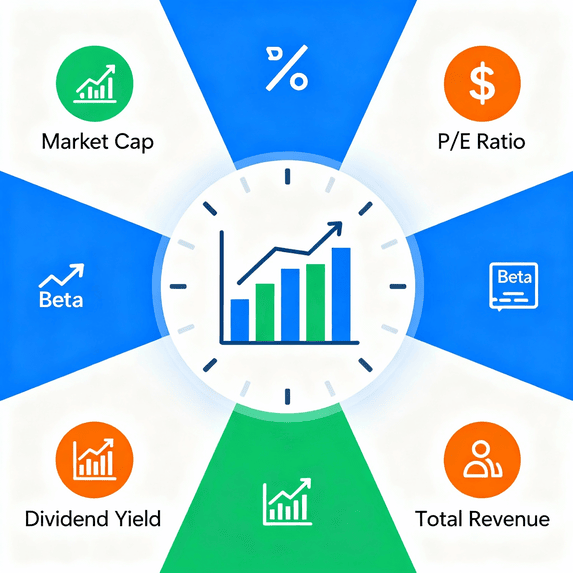

Gather stock data for the selected organization from the past three years using the YFinance library, and visualize this data for enhanced analysis.

> **Your Task**
1. Loop through each company to retrieve stock data of the last three years using the YFinance library.
2. Plot the closing prices for each company.

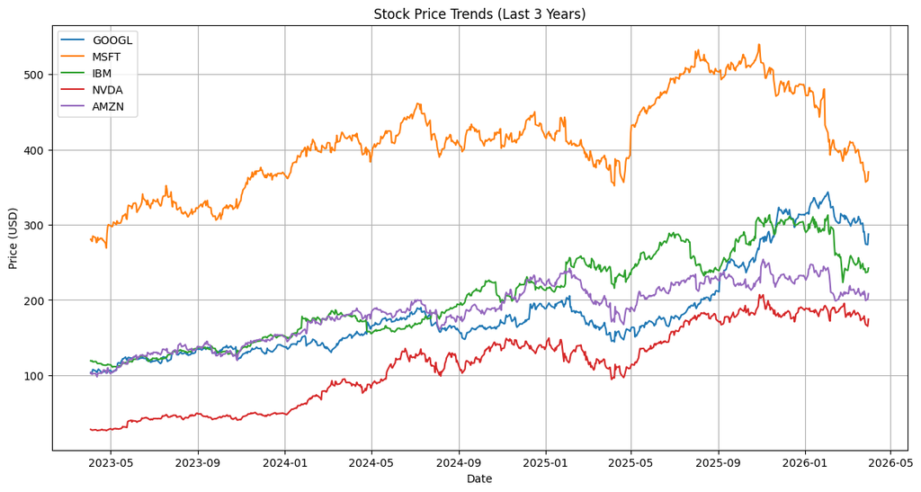

```python
plt.figure(figsize=(14,7))

# Loop through each company and plot closing prices
for symbol in companies:
    ticker = yf.Ticker(symbol)
    data = ticker.history(period="3y")

    # Plot closing price
    plt.plot(data.index, data['Close'], label=symbol)

plt.title("Stock Price Trends (Last 3 Years)")
plt.xlabel("Date")
plt.ylabel("Price (USD)")
plt.legend()
plt.grid(True)
plt.savefig("Stock_Price_Trends_3Y.png")
plt.show()
```

#### **Financial Metrics**

1. **Market Cap:** Total market value of a company’s outstanding shares.
2. **P/E Ratio:** Shows how much investors are willing to pay per dollar of earnings.
3. **Dividend Yield:** Annual dividend income as a percentage of the stock price.
4. **Beta**: Measures a stock’s volatility relative to the overall market.
5. **Total Revenue:** The total income a company generates from its business operations.

> **Your Task**
1. Loop through all the companies to fetch data based on the specified financial metrics.
2. Create a DataFrame (DF) from the collected data.
3. Visualize and compare each financial metric across all companies.
4. For example, visualize and compare the market capitalization for each company.

*Tip: Check `ticker.info` for the available financial metrics*

```python
import pandas as pd
import matplotlib.pyplot as plt

companies = ["GOOGL", "MSFT", "IBM", "NVDA", "AMZN"]
metrics_list = {}

# Fetching the financial metrics
for symbol in companies:                          # Loop through all the companies
    ticker = yf.Ticker(symbol)
    info = ticker.info
    metrics_list[symbol] = {                              # Define the dictionary of all the Finanical Metrics
        "Market Cap": info.get("marketCap", 0),
        "P/E Ratio": info.get("trailingPE", 0),
        "Dividend Yield": info.get("dividendYield", 0),
        "Beta": info.get("beta", 0),
        "Total Revenue": info.get("totalRevenue", 0)
    }
```

```python
# Convert to DataFrame
df = pd.DataFrame(metrics_list).T

# Converting large numbers to billions for readability by divinding the whole column by 1e9
df["Market Cap"] = df["Market Cap"] / 1e9
df["Total Revenue"] = df["Total Revenue"] / 1e9
df["Dividend Yield"] = df["Dividend Yield"] * 100  # Convert to percentage

df   # Printing the df
```

[output not shown]

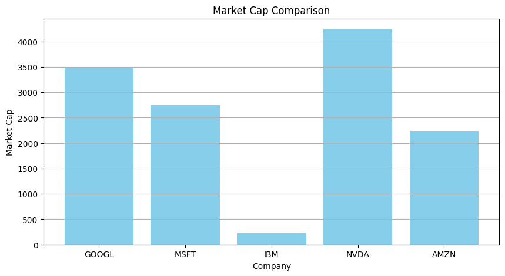

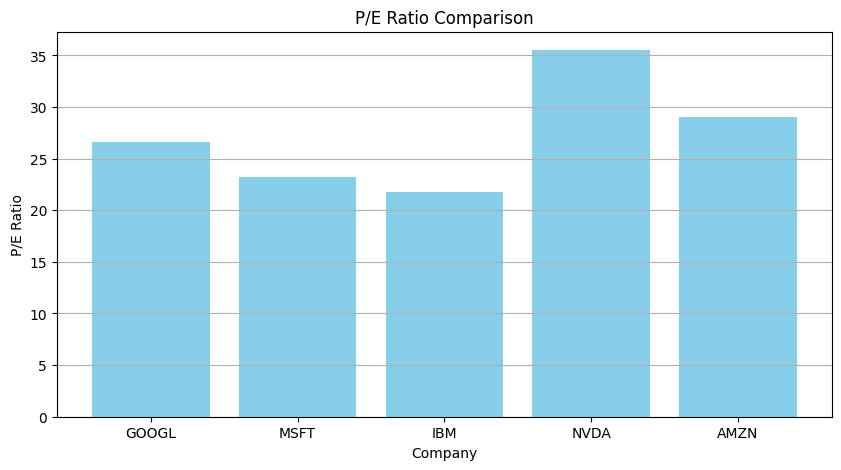

[figure not shown]

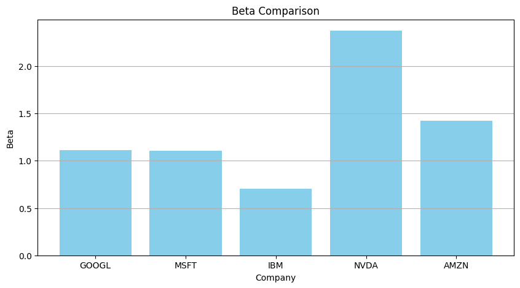

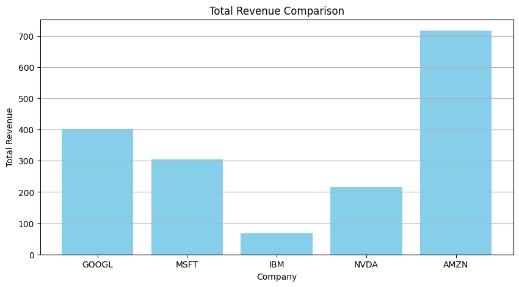

```python
# Plot each metric as a separate bar graph
metrics_to_plot = ["Market Cap", "P/E Ratio", "Dividend Yield", "Beta", "Total Revenue"]

for metric in metrics_to_plot:
    plt.figure(figsize=(10,5))
    plt.bar(df.index, df[metric], color='skyblue')
    plt.title(f"{metric} Comparison")
    plt.ylabel(metric)
    plt.xlabel("Company")
    plt.grid(axis='y')
    plt.show()
```

# **4. RAG-Driven Analysis - 7 Marks**

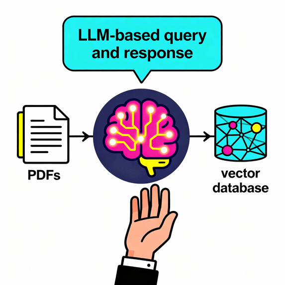

Performing the RAG-Driven Analysis on the AI Initiatives of the companies

> **Your Task**
1. Extract all PDF files from the provided ZIP file.
2. Read the content from each PDF file.
3. Split the content into manageable chunks.
4. Store the chunks in a vector database using embedding functions.
5. Implement a query mechanism on the vector database to retrieve results based on user queries regarding AI initiatives.
6. Evaluate the LLM generated response using LLM-as-Judge

### **A. Loading Company AI Initiative Documents (PDFs) - 1 mark**

```python
# Unzipping the AI Initiatives Documents
import zipfile
with zipfile.ZipFile("Companies-AI-Initiatives.zip", "r") as zip_ref:
    zip_ref.extractall(".")       # Storing all the unzipped contents in this location
```

```python
# Path of all AI Initiative Documents
ai_initiative_pdf_paths = [f"Companies-AI-Initiatives/{file}" for file in os.listdir("Companies-AI-Initiatives")]
ai_initiative_pdf_paths
```

```
['Companies-AI-Initiatives/IBM.pdf',
 'Companies-AI-Initiatives/GOOGL.pdf',
 'Companies-AI-Initiatives/AMZN.pdf',
 'Companies-AI-Initiatives/MSFT.pdf',
 'Companies-AI-Initiatives/NVDA.pdf']
```

```python
from langchain_community.document_loaders import PyPDFDirectoryLoader
loader = PyPDFDirectoryLoader(path = "Companies-AI-Initiatives")          # Creating an PDF loader object
```

```python
# Defining the text splitter
text_splitter = RecursiveCharacterTextSplitter.from_tiktoken_encoder(
    encoding_name='cl100k_base',
    chunk_size=1000,
    chunk_overlap=200
)
```

```python
# Splitting the chunks using the text splitter
ai_initiative_chunks = loader.load_and_split(text_splitter)
```

```python
# Total length of all the chunks
len(ai_initiative_chunks)
```

```
62
```

### **B. Vectorizing AI Initiative Documents with ChromaDB - 1 mark**

```python
# Defining the 'text-embedding-ada-002' as the embedding model
from langchain_openai import OpenAIEmbeddings
embedding_model = OpenAIEmbeddings(model="text-embedding-ada-002")
```

```python
#  Creating a Vectorstore, storing all the above created chunks using an embedding model
vectorstore = Chroma.from_documents(
    ai_initiative_chunks,
    embedding_model,
    collection_name="AI_Initiatives"
)

# Ignore if it gives an error or warning
```

[output not shown]

```python
# Creating an retriever object which can fetch ten similar results from the vectorstore
retriever = vectorstore.as_retriever(
    search_type="similarity",
    search_kwargs={"k": 10}
)
```

### **C. Retrieving relevant Documents - 3 marks**

```python
user_message = "Give me the best project that `IBM` company is working upon"
```

```python
# Building the context for the query using the retrieved chunks
relevant_document_chunks = retriever.get_relevant_documents(user_message)
context_list = [d.page_content for d in relevant_document_chunks]
context_for_query = ". ".join(context_list)
```

```python
len(relevant_document_chunks)
```

```
10
```

```python
# Write a system message for an LLM to help craft a response from the provided context
qna_system_message = """

You are a retrieval-based Q&A assistant for a dataset of company AI initiatives.

Instructions:
- Answer strictly from the retrieved context.
- Do not use prior knowledge.
- If the context is incomplete or does not contain the answer, clearly say so.
- Do not hallucinate, infer hidden facts, or fill gaps.
- Prefer precise, factual responses.
- Include relevant company names, AI initiative names, dates, and outcomes when present in the context.
- For comparison questions, compare only what is explicitly supported by the context.
- For summary questions, provide a concise synthesis grounded in the context.

Response rules:
- Be professional, clear, and concise.
- Cite the relevant details from the context in natural language.
- If multiple documents conflict, mention that the documents provide differing information.


"""
```

```python
# Write an user message template which can be used to attach the context and the questions
qna_user_message_template = """
###Context
Here are some documents that are relevant to the question mentioned below.
{context}

###Question
{question}
"""
```

```python
# Format the prompt
formatted_prompt = f"""[INST]{qna_system_message}\n
                {'user'}: {qna_user_message_template.format(context=context_for_query, question=user_message)}
                [/INST]"""
```

```python
# Make the LLM call
resp = llm.invoke(formatted_prompt)
resp.content
```

[output not shown]

```python
# Define RAG function
def RAG(user_message):
    """
    Args:
    user_message: Takes a user input for which the response should be retrieved from the vectorDB.
    Returns:
    relevant context as per user query.
    """
    relevant_document_chunks = retriever.get_relevant_documents(user_message)
    context_list = [d.page_content for d in relevant_document_chunks]
    context_for_query = ". ".join(context_list)



    # Combine qna_system_message and qna_user_message_template to create the prompt
    prompt = f"""[INST]{qna_system_message}\n
                {'user'}: {qna_user_message_template.format(context=context_for_query, question=user_message)}
                [/INST]"""

    # Quering the LLM
    try:
        response = llm.invoke(prompt)

    except Exception as e:
        response = f'Sorry, I encountered the following error: \n {e}'

    return response.content
```

```python
# Test Cases
print(RAG("How is the area in which GOOGL is working different from the area in which MSFT is working?"))
```

```
Google (GOOGL) and Microsoft (MSFT) are both engaged in artificial intelligence initiatives, but they focus on different areas within the AI landscape.

**Google's Focus:**
- Google emphasizes a broad AI ecosystem that includes natural language processing, computer vision, speech recognition, and generative AI.
- Key initiatives include **Gemini**, which is a family of multimodal foundation models designed to enhance reasoning and generative capabilities across text, images, and code. Gemini integrates with various consumer products like Google Search and Google Workspace.
- Another initiative is **Project Astra**, which aims to improve multimodal interaction and accessibility across devices.

**Microsoft's Focus:**
- Microsoft concentrates on integrating AI into its software products to enhance productivity. This includes leveraging large language models through tools like **Microsoft 365 Copilot**, which assists users in applications such as Word and Excel by automating tasks.
- Additionally, Microsoft has developed the **Azure AI Foundry Labs**, an experimental platform aimed at translating advanced research into practical applications for developers and enterprises.

In summary, while both companies are advancing their AI capabilities significantly:
- Google's efforts are more focused on developing foundational models that integrate across various consumer services.
- Microsoft's approach centers around enhancing productivity tools within its existing software suite through direct integration of AI functionalities.
```

```python
print(RAG("What are the three projects on which MSFT is working upon?"))
```

```
Microsoft is working on the following three AI initiatives:

1. **Azure AI Foundry Labs**: This is an experimental AI platform aimed at accelerating the translation of advanced AI research into real-world applications. It serves as a collaborative hub for developers, startups, enterprises, and Microsoft Research teams.

2. **Microsoft 365 Copilot**: An AI-powered productivity assistant embedded across Microsoft 365 applications such as Word, Excel, PowerPoint, Outlook, and Teams. It leverages large language models to enhance productivity by automating tasks and providing intelligent assistance.

3. **GitHub Copilot**: An AI-powered coding assistant developed by GitHub in collaboration with OpenAI that suggests code completions and provides conversational assistance through features like Copilot Chat.

These projects reflect Microsoft's commitment to integrating AI across its ecosystem to improve efficiency and innovation in various domains.
```

```python
print(RAG("What is the timeline of each project in NVDA?"))
```

```
The timeline for each project in NVIDIA (NVDA) is as follows:

1. **Project G-Assist**:
   - **Concept & Demo Phase**: Early prototypes were teased in NVIDIA showcases tied to RTX AI initiatives.
   - **Public Availability**: G-Assist became accessible via the NVIDIA App in 2024–2025, marking the first time consumers could interact with the assistant at scale.
   - **Iterative Updates**: Throughout 2024 and 2025, NVIDIA improved memory efficiency, broadened GPU compatibility, and launched plugin SDKs.

2. **NVIDIA DLSS 4**:
   - The document does not provide specific dates for its development phases but states that as of 2025, DLSS 4 is fully available and integrated into many new AAA titles. It continues to expand through partnerships with major publishers.

No exact start dates or detailed timelines are provided for either project beyond these milestones.
```

```python
print(RAG("What are the areas in which AMZN is investing when it comes to AI?"))
```

```
Amazon (AMZN) is investing in several areas related to artificial intelligence (AI), as detailed in the context:

1. **Retail Enhancements**: AI is used for product recommendations, dynamic pricing, fraud detection, and supply chain optimization to make shopping faster and more personalized.

2. **Amazon Web Services (AWS)**: AWS offers AI and machine learning tools that help businesses build intelligent applications across various domains such as natural language processing and computer vision.

3. **Voice Assistant Technology**: Innovations like Alexa leverage AI for understanding speech and performing tasks.

4. **Robotics**: AI-driven robotics are utilized in warehouses to streamline order fulfillment processes.

5. **Generative AI Initiatives**:
   - **Amazon SageMaker**: A fully managed service that simplifies building, training, and deploying machine learning models at scale.
   - **Amazon Bedrock**: A serverless platform launched in 2023 for developing generative AI applications with access to a variety of foundation models from leading companies.
   - **Project Olympus**: A multimodal AI model capable of processing text, images, and videos simultaneously aimed at enhancing search functionalities across platforms.

These investments reflect Amazon's commitment to advancing its capabilities in both consumer-facing services and enterprise solutions through innovative uses of artificial intelligence technology.
```

```python
print(RAG("What are the risks associated with projects within GOOG?"))
```

```
The risks associated with projects within Google (GOOG) as mentioned in the context include:

1. **Privacy Concerns**: Processing live video and audio data raises significant privacy issues, necessitating robust data protection measures.

2. **Technical Hurdles**: Achieving real-time, accurate multimodal understanding requires overcoming complex AI and hardware challenges.

3. **User Acceptance**: Gaining user trust and acceptance for a new form of AI assistant that interacts in more personal and potentially intrusive ways is crucial.

4. **Regulatory Compliance**: Navigating the evolving landscape of AI regulations and ensuring compliance with global standards poses a challenge.

5. **Model Safety**: Risks such as hallucinations and factual inaccuracies require constant evaluation and moderation to ensure safety.

6. **Regulatory Scrutiny**: Integrations into products like Chrome and Workspace could attract antitrust scrutiny or regulatory attention regarding AI usage.

7. **Compute Costs**: High-performing models necessitate significant energy consumption and infrastructure investment, increasing operational costs.

8. **Competition**: Maintaining differentiation amid competitors like OpenAI, Meta, Anthropic, among others is essential for market positioning.

These risks highlight the complexities involved in developing advanced AI initiatives at Google while ensuring user trust, compliance with regulations, technical feasibility, safety of models, cost management, and competitive advantage.
```

### **D. Evaluation of the RAG - 2 marks**

```python
# Writing a question for performing evaluations on the RAG
evaluation_test_question = "What are the three projects on which MSFT is working upon?"
```

```python
# Building the context for the evaluation test question using the retrieved chunks
relevant_document_chunks = retriever.get_relevant_documents(evaluation_test_question)
context_list = [d.page_content for d in relevant_document_chunks]
context_for_query = ". ".join(context_list)
```

```python
# Default RAG Answer
answer = RAG(evaluation_test_question)
print(answer)
```

```
Microsoft is currently working on the following three AI initiatives:

1. **Azure AI Foundry Labs**: This experimental platform aims to accelerate the translation of advanced AI research into real-world applications, providing a collaborative hub for developers and enterprises to prototype, test, and deploy AI solutions.

2. **Microsoft 365 Copilot**: An AI-powered productivity assistant integrated across Microsoft 365 applications (such as Word, Excel, PowerPoint), it enhances productivity by automating repetitive tasks and providing intelligent assistance based on large language models.

3. **GitHub Copilot**: Developed in collaboration with OpenAI, this coding assistant suggests code completions and provides conversational support for developers within GitHub's environment.

These projects reflect Microsoft's commitment to embedding AI across its ecosystem while focusing on enhancing productivity and innovation.
```

```python
# Defining user messsage template for evaluation
evaluation_user_message_template = """
###Question
{question}

###Context
{context}

###Answer
{answer}
"""
```

##### **1. Groundedness**

```python
# Writing the system message and the evaluation metrics for checking the groundedness
groundedness_rater_system_message = """

You are an evaluator for a Retrieval-Augmented Generation (RAG) system.

Your task is to judge how well the assistant's answer is grounded in the retrieved context.

You will be given:
1. A user question
2. Retrieved context passages
3. The assistant's answer

Evaluate whether the answer is fully supported by the retrieved context and does not include unsupported, fabricated, or exaggerated claims.

Scoring rubric for Groundedness:
- 5 = Fully grounded. Every substantive claim in the answer is directly supported by the retrieved context.
- 4 = Mostly grounded. Nearly all claims are supported; minor wording or inference goes slightly beyond the context but remains reasonable.
- 3 = Partially grounded. Some important claims are supported, but others are weakly supported, inferred too far, or ambiguous.
- 2 = Weakly grounded. Several key claims are unsupported or contradicted by the retrieved context.
- 1 = Not grounded. The answer is largely hallucinated, unsupported, or clearly contradicted by the context.

Instructions:
- Focus only on whether the answer is supported by the retrieved context.
- Do not judge whether the answer is generally true outside the provided context.
- Penalize unsupported details, invented facts, and overconfident conclusions.
- Allow light paraphrasing if the meaning is clearly supported.
- If the answer omits relevant information, that is not a groundedness problem unless the included claims are unsupported.

Return your evaluation in this JSON format only:
{
  "groundedness_score": <1-5>,
  "verdict": "<fully_grounded|mostly_grounded|partially_grounded|weakly_grounded|not_grounded>",
  "explanation": "<brief explanation>",
  "unsupported_claims": ["<claim 1>", "<claim 2>"],
  "supported_claims": ["<claim 1>", "<claim 2>"]
}

Question:
{{question}}

Retrieved Context:
{{context}}

Assistant Answer:
{{answer}}


"""
```

```python
# Combining groundedness_rater_system_message + llm_prompt + answer for evaluation
groundedness_prompt = f"""[INST]{groundedness_rater_system_message}\n
            {'user'}: {evaluation_user_message_template.format(context=context_for_query, question=evaluation_test_question, answer=answer)}
            [/INST]"""
```

```python
# Defining a new LLM object
groundness_checker = ChatOpenAI(
    model="gpt-4o-mini",
    temperature=0,
    max_tokens=500,
    top_p=0.95,
    frequency_penalty=1.2,
    stop_sequences=['INST']
)

# Using the LLM-as-Judge for evaluating Groundedness
groundness_response = groundness_checker.invoke(groundedness_prompt)
print(groundness_response.content)
```

```
{
  "groundedness_score": 5,
  "verdict": "fully_grounded",
  "explanation": "The assistant's answer accurately lists the three AI initiatives that Microsoft is working on, providing a brief description of each. All claims made in the answer are directly supported by the retrieved context.",
  "unsupported_claims": [],
  "supported_claims": [
    "Microsoft is currently working on Azure AI Foundry Labs, which aims to accelerate AI research into real-world applications.",
    "Microsoft 365 Copilot is an AI-powered productivity assistant integrated across Microsoft 365 applications.",
    "GitHub Copilot suggests code completions and provides conversational support for developers."
  ]
}
```

##### **2. Relevance**

```python
# Writing the system message and the evaluation metrics for checking the relevance
relevance_rater_system_message = """

You are an evaluator for a Retrieval-Augmented Generation (RAG) system.

Your task is to judge how relevant the assistant's answer is to the user's question.

You will be given:
1. A user question
2. Retrieved context passages
3. The assistant's answer

Evaluate whether the assistant's answer directly addresses the user's question and stays focused on what was asked.

Scoring rubric for Relevance:
- 5 = Highly relevant. The answer directly and completely addresses the user's question with no meaningful off-topic content.
- 4 = Mostly relevant. The answer addresses the question well, with only minor unnecessary or loosely related details.
- 3 = Partially relevant. The answer addresses part of the question, but misses important aspects or includes noticeable irrelevant content.
- 2 = Weakly relevant. The answer only slightly addresses the question or is mostly off-topic.
- 1 = Not relevant. The answer fails to address the user's question.

Instructions:
- Focus on how well the answer responds to the user's question.
- Do not penalize the answer for factual errors unless they make the answer irrelevant.
- Do not focus on whether the answer is supported by the retrieved context; judge relevance only.
- Reward answers that are direct, focused, and complete with respect to the question.
- Penalize answers that are vague, off-topic, incomplete, or overly generic.

Return your evaluation in this JSON format only:
{
  "relevance_score": <1-5>,
  "verdict": "<highly_relevant|mostly_relevant|partially_relevant|weakly_relevant|not_relevant>",
  "explanation": "<brief explanation>",
  "missing_aspects": ["<aspect 1>", "<aspect 2>"],
  "irrelevant_content": ["<content 1>", "<content 2>"]
}

Question:
{{question}}

Retrieved Context:
{{context}}

Assistant Answer:
{{answer}}


"""
```

```python
# Combining relevance_rater_system_message + llm_prompt + answer for evaluation
relevance_prompt = f"""[INST]{relevance_rater_system_message}\n
            {'user'}: {evaluation_user_message_template.format(context=context_for_query, question=evaluation_test_question, answer=answer)}
            [/INST]"""
```

```python
# Defining a new LLM object
relevance_checker = ChatOpenAI(
    model="gpt-4o-mini",
    temperature=0,
    max_tokens=500,
    top_p=0.95,
    frequency_penalty=1.2,
    stop_sequences=['INST']
)

# Using the LLM-as-Judge for evaluating Relevance
relevance_response = relevance_checker.invoke(relevance_prompt)
print(relevance_response.content)
```

```
{
  "relevance_score": 5,
  "verdict": "highly_relevant",
  "explanation": "The assistant's answer directly and completely addresses the user's question by clearly listing the three projects Microsoft is working on, along with brief descriptions of each initiative. There are no off-topic details or irrelevant content.",
  "missing_aspects": [],
  "irrelevant_content": []
}
```

# **5. Scoring and Ranking - 3 Marks**

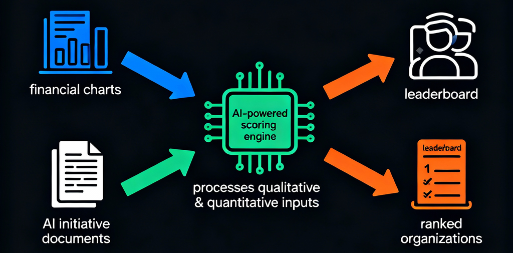

Prompting an LLM to score each company by integrating Quantitative data (stock trend, growth metrics) and Qualitative evidence (PDF insights)

> **Your Task**
1. Write a system message and a user message that outlines the required data for the prompt.
2. Prompt the LLM to rank and recommend companies for investment based on the provided PDF and stock data to achieve better returns.

```python
# Fetching all the links of the documents
len(vectorstore.get()['documents'])
```

```
62
```

```python
# Write a system message for instructing the LLM for scoring and ranking the companies
system_message = """

You are a financial research and ranking assistant.

Your role is to evaluate, score, and rank companies in a dataset by combining:
1. Quantitative data, such as stock trend, revenue growth, profitability, margins, momentum, valuation, or other structured financial indicators
2. Qualitative evidence extracted from PDFs, such as management commentary, business strategy, product strength, competitive position, risk factors, market outlook, and operational execution

Your objective is to produce a balanced company assessment that integrates both numeric performance and document-based evidence.

Instructions:
- Evaluate each company independently first, then compare companies consistently using the same criteria.
- Use both quantitative and qualitative inputs in every assessment whenever available.
- Do not rely only on stock price movement; treat stock trend as one signal among many.
- Give more weight to durable business strength, financial performance, and clearly supported qualitative evidence than to short-term hype or isolated statements.
- Prefer evidence-based reasoning over speculation.
- If qualitative evidence from the PDFs conflicts with quantitative trends, explicitly note the conflict and reflect that uncertainty in the score.
- If data is missing, incomplete, or weak, state that clearly and avoid overstating confidence.
- Do not invent facts beyond the provided dataset and PDF evidence.

Scoring framework:
Score each company on a scale from 0 to 100 using the following dimensions:
- Financial Strength: profitability, margins, cash flow, balance sheet quality
- Growth: revenue growth, earnings growth, expansion potential
- Market Performance: stock trend, momentum, relative performance, market confidence
- Qualitative Strength: strategic positioning, leadership direction, product/business quality, competitive moat
- Risk: operational, financial, regulatory, market, or execution risks

Weighting guidance:
- Financial Strength: 25%
- Growth: 25%
- Market Performance: 15%
- Qualitative Strength: 25%
- Risk: 10% negative adjustment or risk-moderated factor

You may adjust weighting slightly if the task context suggests a different emphasis, but remain consistent across companies.

Output requirements:
For each company, provide:
- Company name
- Overall score (0-100)
- Rank relative to peers
- Short investment-style summary
- Quantitative rationale
- Qualitative rationale
- Key risks
- Confidence level: High, Medium, or Low

Ranking rules:
- Rank companies from strongest to weakest based on overall evidence.
- Break ties using stronger financial quality first, then stronger qualitative evidence.
- Be explicit about why one company ranks above another.
- Keep explanations concise but specific.

Reasoning principles:
- Synthesize the evidence instead of listing raw facts.
- Highlight the most decision-relevant signals.
- Distinguish between strong evidence, weak evidence, and inference.
- Avoid overly promotional or overly pessimistic language.
- Maintain an analytical, neutral, and evidence-driven tone.

If requested, return results in a structured table or JSON format.


 """
```

```python
# Write a user message for instructing the LLM for scoring and ranking the companies
user_message = f"""

Analyze the companies in the provided information and rank them from strongest to weakest overall opportunity.

Your task is to score each company by combining:
- Quantitative financial data from the table
- Qualitative evidence from the AI initiatives documents

Instructions:
- Evaluate every company using both sources whenever possible
- Use a consistent scoring approach across all companies
- Consider factors such as stock trend, growth, profitability, momentum, and overall financial strength from the financial data
- Consider factors such as strategic direction, AI adoption, execution quality, competitive positioning, and business potential from the AI initiatives
- Do not rely on only one metric or one source
- If the evidence is incomplete, mixed, or conflicting, note that and lower your confidence
- Do not make up facts that are not supported by the provided data

For each company, provide:
- Company name
- Overall score from 0 to 100
- Rank
- Short summary
- Quantitative rationale
- Qualitative rationale
- Key risks
- Confidence level

After evaluating all companies, provide:
- A final ranked list from best to worst
- A short explanation of why the top-ranked company placed first
- A short explanation of why the lowest-ranked company placed last

Return the results in a clear, well-structured format.


---
### 1. Financial Data
{df.to_string()}

---
### 2. AI Initiatives
{vectorstore.get()['documents']}
"""
```

```python
# Formatting the prompt
formatted_prompt = f"""[INST]{system_message}\n
                {'user'}: {user_message}
                [/INST]"""
```

```python
# Calling the LLM
recommendation = llm.invoke(formatted_prompt)
recommendation.content
```

[output not shown]

```python
print(recommendation.content)
```

[output not shown]

# **6. Summary and Future Scope - 4 Marks**

Based on the project, learners are expected to share their observations, key learnings, and insights related to the business use case, including any challenges they encountered. Additionally, they should recommend improvements to the project and suggest further steps for enhancement.

**A. Summary / Your Observations about this Project - 2 Marks**

1. If you want to do something complex, most probably there's a library for that such as the plotting library. I will for sure investigate for libraries before trying to resolve on my own.
2. A key learning for me is the scope of the term "Prompt Engineering" which -before taking this course- I thought was just about knowing how to write a prompt (Context, Ask, Examples, Output Format), but it goes well beyond that since prompts are used everywhere. Not only to ask about a certain dataset, but to verify the results are grounded and accurate as well. I learned that we can evaluate performance of our solution by providing LLMs with processing results programatically along with the expectations we have on them so the LLM can verify.
3. RAGs are a cornerstone concept in the rapid development of AI, it provided the mechanisms to 'expand' the knowledge base of a model without needing to re-train. I now understand that RAGs are probably the element we now interact the most with (without knowing) primarily in enterprises where we need to summarize meetings, documents or internal chats. I also now understand the internal hype at my job about 'evals', which is the latter part of this lab, to make sure our tools are accurate since that removes the human-in-the-middle more and more over time.

**B. Future scope of this Project - 2 Marks**

1. I'm curious to challenge myself about setting up a proper RAG + LLM solution outside of a .ipynb file. Notebooks are convenient for learning, but are not how things are done in the real world.
2. A bit more of a challenging scenario could be to ask the student to bring their own data of a topic of interest. For example, I like baseball and it produces a lot of data every year that is publicly available. I'd love to play with some of that as part of the project so it gets more challenging to find the answers I need to make progress.
3. Would have been great to have some DSPy section where we get to use that. I found it super convenient in the materials I reviwed and the Mentored Learning Session.